# Segundo Trabajo - Técnicas de Aprendizaje Estadístico

## Ejercicio 6

**Al final de la Sección 9.6.1, se afirma que en el caso de los datos que son apenas separables linealmente, un clasificador de vectores de soporte con un pequeño valor de “costo” que clasifica erróneamente un par de observaciones de entrenamiento puede tener un mejor rendimiento en los datos de prueba que uno con un gran valor de “costo” que no clasifique erróneamente ninguna observación de capacitación. Ahora investigará esa afirmación.**

**a) Genere datos de dos clases con p=2 de tal manera que las clases sean apenas linealmente separables.**

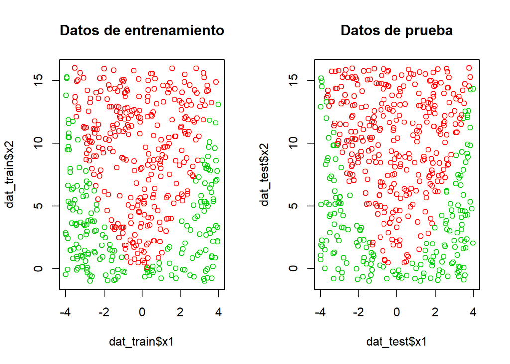

**b) Calcule las tasas de error de validación cruzada para los clasificadores de vectores de soporte con un rango de valores de “costo”. ¿Cuántos errores de capacitación se clasifican erróneamente para cada valor de “costo” considerado y cómo se relaciona esto con los errores de validación cruzada obtenidos?**

```
##
## Parameter tuning of 'svm':
##
## - sampling method: 10-fold cross validation
##
## - best parameters:
##  cost
##   0.1
##
## - best performance: 0.25
##
## - Detailed performance results:
##    cost error dispersion
## 1 1e-03 0.398 0.06425643
## 2 1e-02 0.256 0.06239658
## 3 1e-01 0.250 0.06128259
## 4 1e+00 0.250 0.06128259
## 5 5e+00 0.250 0.06128259
## 6 1e+01 0.250 0.06128259
## 7 1e+02 0.250 0.06128259
## 8 1e+04 0.398 0.06425643
```

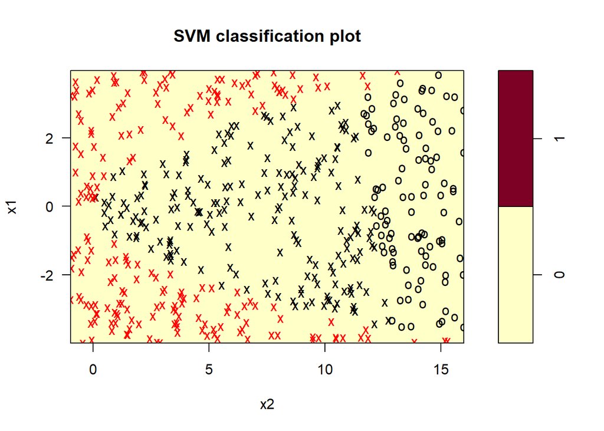

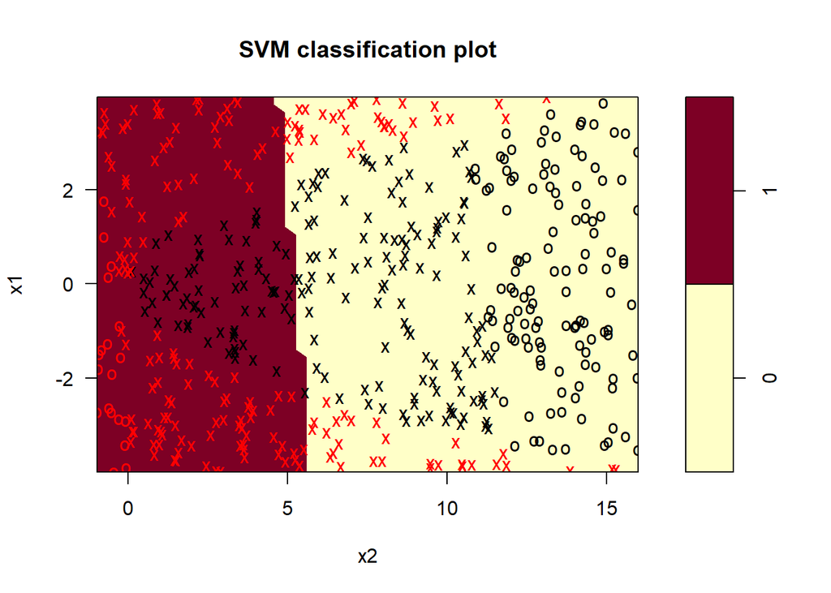

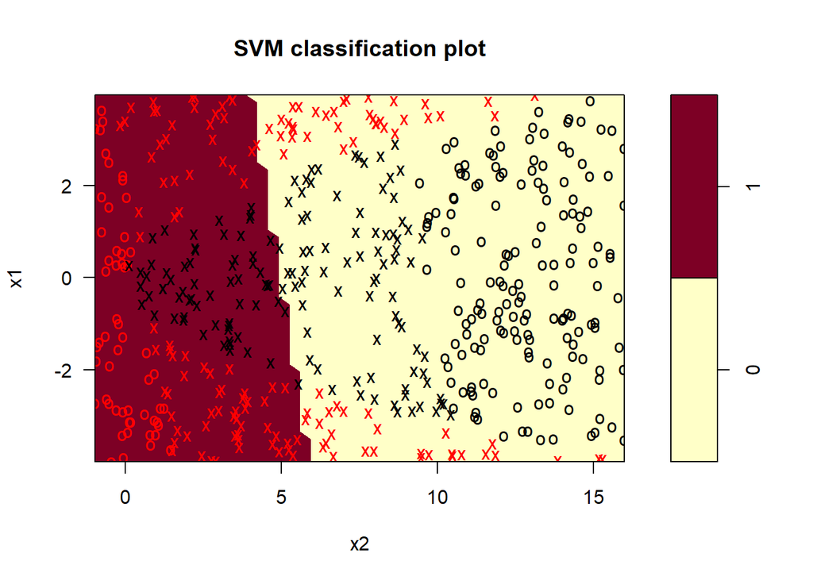

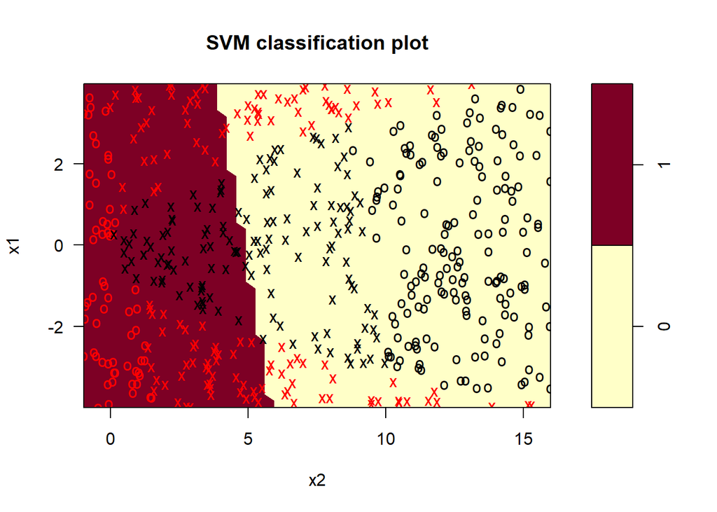

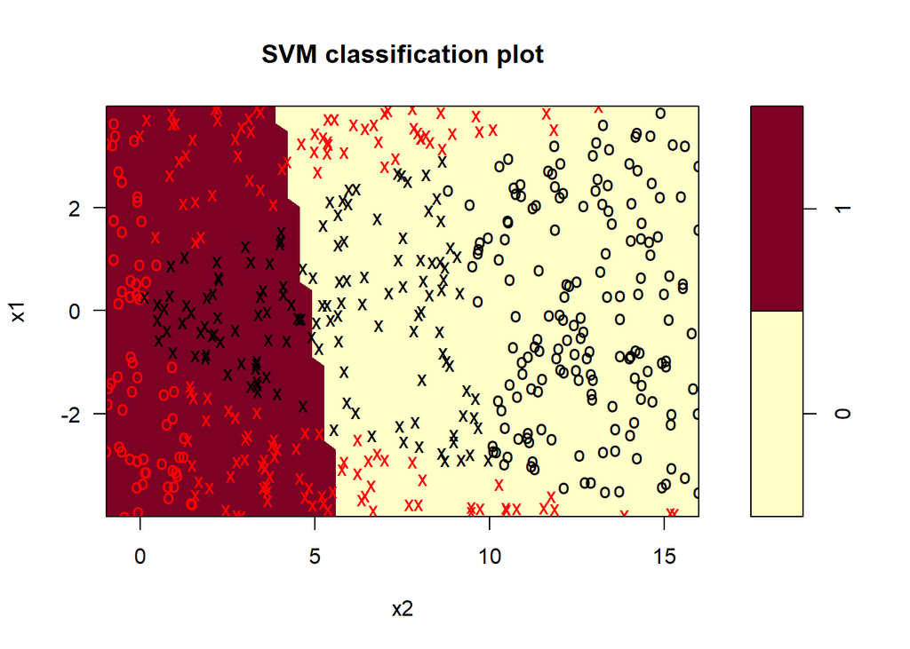

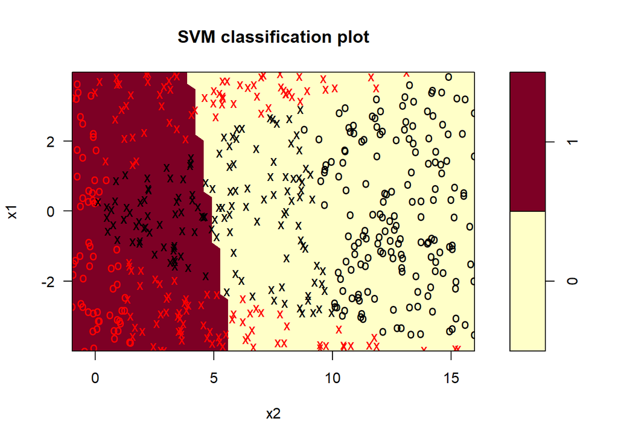

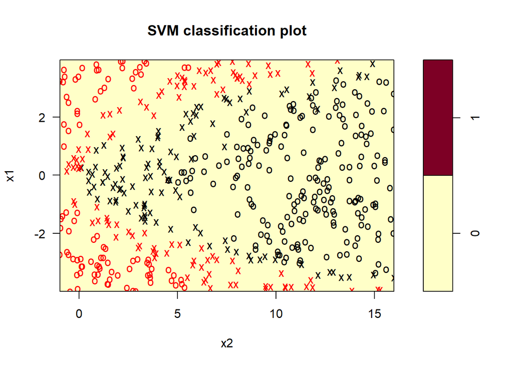

```
## [1] 0.398 0.254 0.252 0.252 0.254 0.254 0.254 0.398
```

```
## [1] "El costo 0.1 tiene el mínimo error de : 0.252"
```

**c)Genere un conjunto de datos de prueba adecuado y calcule los errores de prueba correspondientes a cada uno de los valores de costo considerados. ¿Qué valor del costo conduce a la menor cantidad de errores de prueba, y cómo se compara esto con los valores de costo que producen la menor cantidad de errores de capacitación y la menor cantidad de errores de validación cruzada?**

```
## [1] 0.366 0.184 0.194 0.194 0.196 0.196 0.196 0.366
```

```
## [1] "El costo 0.01 tiene el mínimo error de pruebas: 0.184"
```

**d) Comente los reusltados.**

Se observa que con un kernel lineal con costos pequeños o grandes el error de prueba es pequeño, pero si el costo es demasiado pequeño o demasiado grande, el error es alto.

## Ejercicio 7

**En este problema, utilizará SVM para predecir si un automóvil determinado obtiene un consumo de combustible alto o bajo en función del conjunto de datos “Auto”.**

**a) Cree una variable binaria que tome un 1 para los automóviles con millaje de gasolina por encima de la mediana, y un 0 para automóviles con millaje de gasolina por debajo de la mediana.**

**b) Ajuste un clasificador de vector de soporte a los datos con varios valores de “costo”, con el fin de predecir si un automóvil tiene un alto rendimiento de bajo consumo de combustible. Informe los errores de validación cruzada asociados con diferentes valores de este parámetro. Comenta tus resultados.**

```
##
## Parameter tuning of 'svm':
##
## - sampling method: 10-fold cross validation
##
## - best parameters:
##  cost
##     1
##
## - best performance: 0.0075
##
## - Detailed performance results:
##    cost      error dispersion
## 1 1e-02 0.07391026 0.05301906
## 2 1e-01 0.04326923 0.03594224
## 3 1e+00 0.00750000 0.01687371
## 4 5e+00 0.01519231 0.01760469
## 5 1e+01 0.01775641 0.01700310
## 6 1e+02 0.03044872 0.02842322
## 7 1e+03 0.03044872 0.02842322
```

**c) Ahora repita (b), esta vez usando SVM con núcleos radiales y polinomiales, con diferentes valores de “gamma” y “grado” y “costo”. Comenta tus resultados.**

SVM Polinominal

```
##
## Parameter tuning of 'svm':
##
## - sampling method: 10-fold cross validation
##
## - best parameters:
##  cost degree
##   100      2
##
## - best performance: 0.2989103
##
## - Detailed performance results:
##     cost degree     error dispersion
## 1  1e-02      2 0.5967949 0.05312225
## 2  1e-01      2 0.5967949 0.05312225
## 3  1e+00      2 0.5967949 0.05312225
## 4  5e+00      2 0.5967949 0.05312225
## 5  1e+01      2 0.5814103 0.05427855
## 6  1e+02      2 0.2989103 0.09318496
## 7  1e-02      3 0.5967949 0.05312225
## 8  1e-01      3 0.5967949 0.05312225
## 9  1e+00      3 0.5967949 0.05312225
## 10 5e+00      3 0.5967949 0.05312225
## 11 1e+01      3 0.5967949 0.05312225
## 12 1e+02      3 0.3503846 0.14011367
## 13 1e-02      4 0.5967949 0.05312225
## 14 1e-01      4 0.5967949 0.05312225
## 15 1e+00      4 0.5967949 0.05312225
## 16 5e+00      4 0.5967949 0.05312225
## 17 1e+01      4 0.5967949 0.05312225
## 18 1e+02      4 0.5967949 0.05312225
```

Para el kernel polinomial vemos que el minimo error se encuentra con costo de 100.

SVM Radial

```
##
## Parameter tuning of 'svm':
##
## - sampling method: 10-fold cross validation
##
## - best parameters:
##  cost gamma
##   100  0.01
##
## - best performance: 0.01512821
##
## - Detailed performance results:
##     cost gamma      error dispersion
## 1  1e-02 1e-02 0.59679487 0.05312225
## 2  1e-01 1e-02 0.09442308 0.05666871
```

[output cut: 34 more lines]

Para el kernel radial, vemos que el minimo error se encuentra con costo de 100.

**d) Haga algunos gráficos para respaldar sus afirmaciones en (b) y (c).**

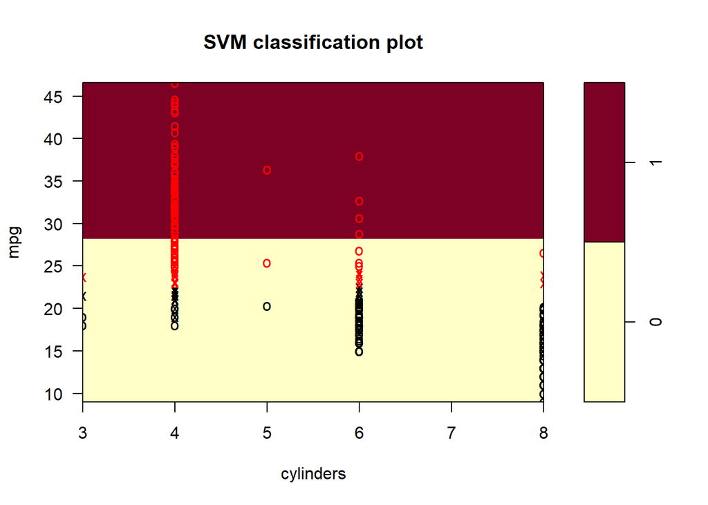

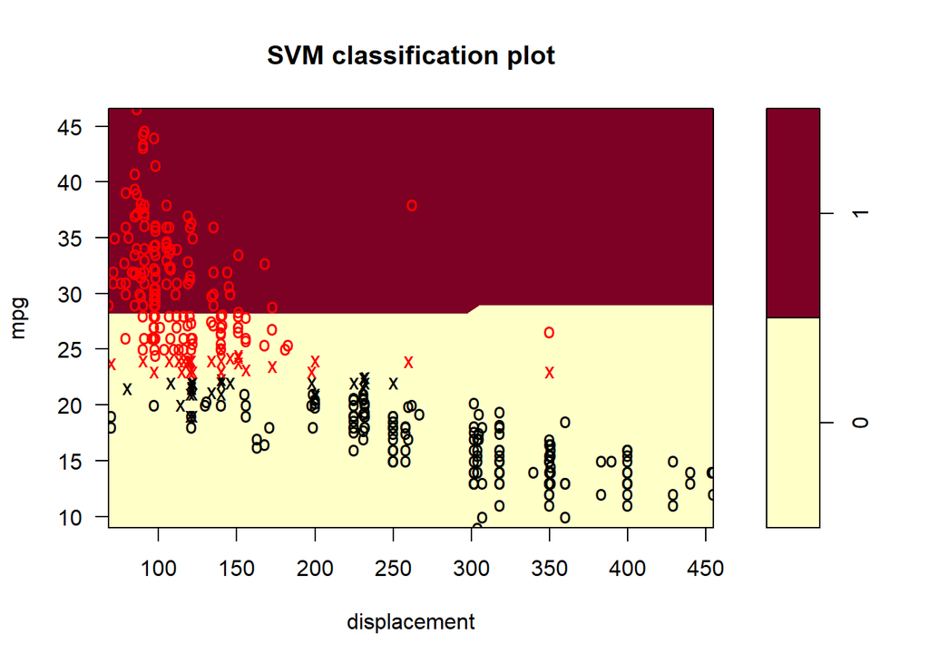

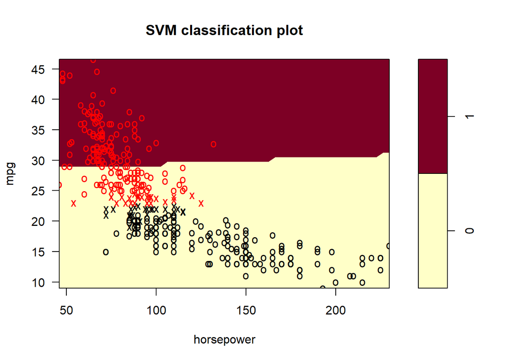

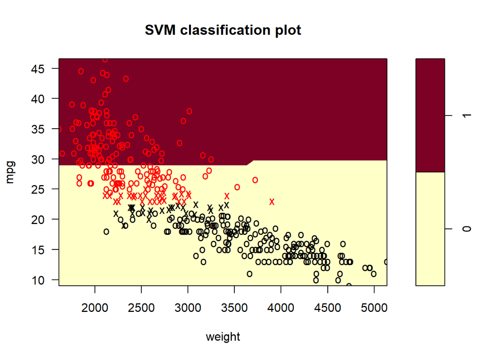

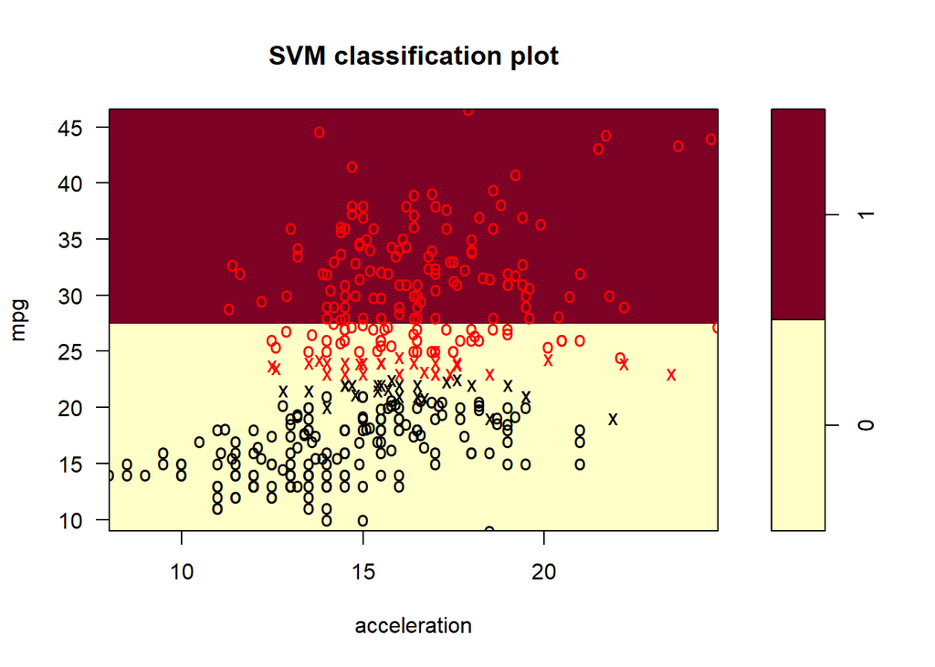

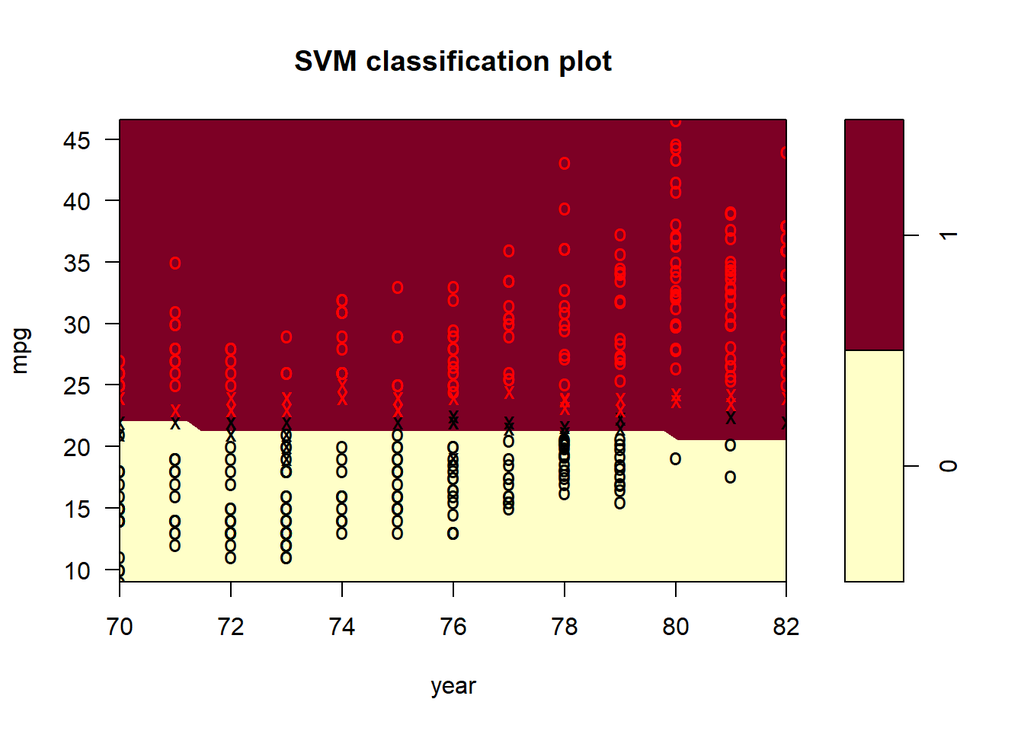

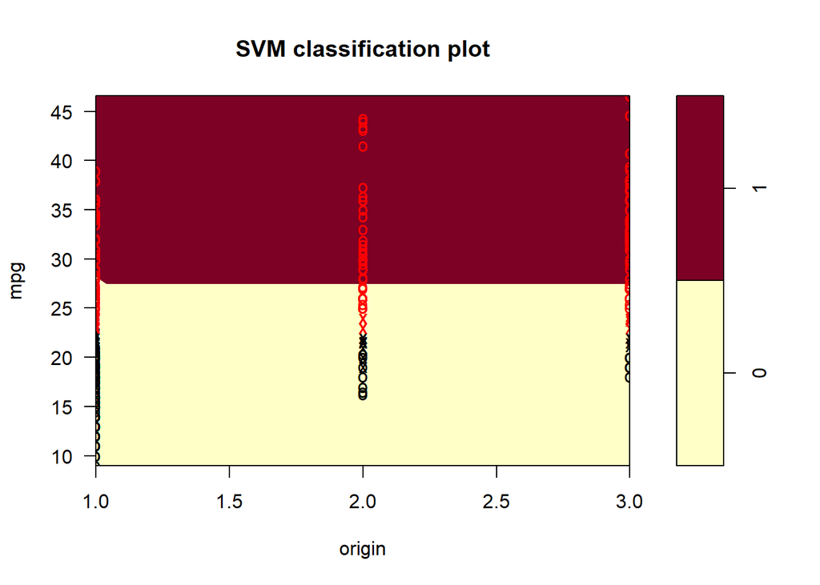

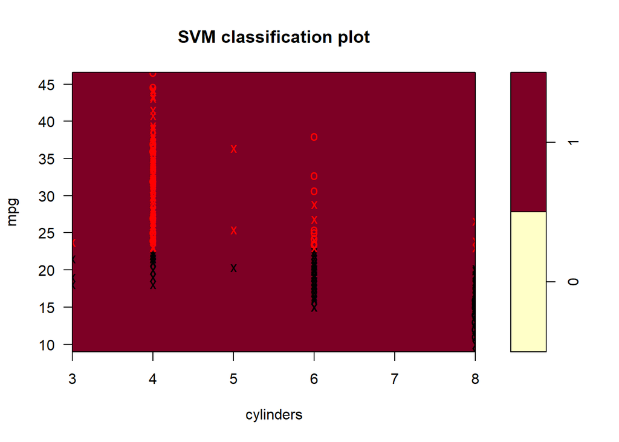

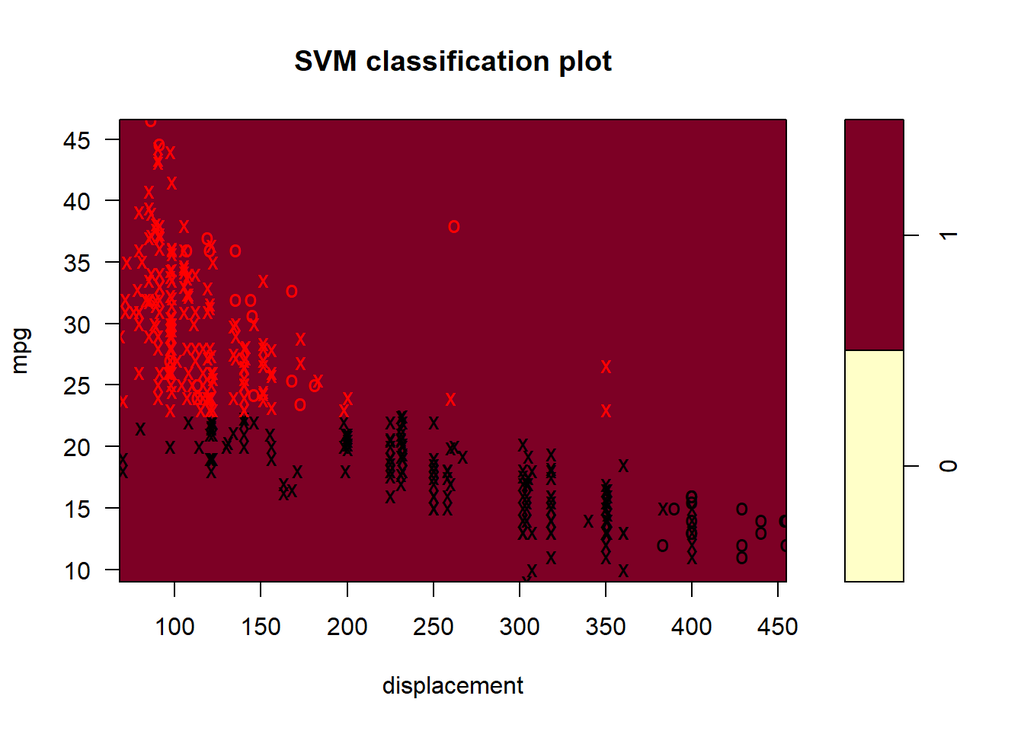

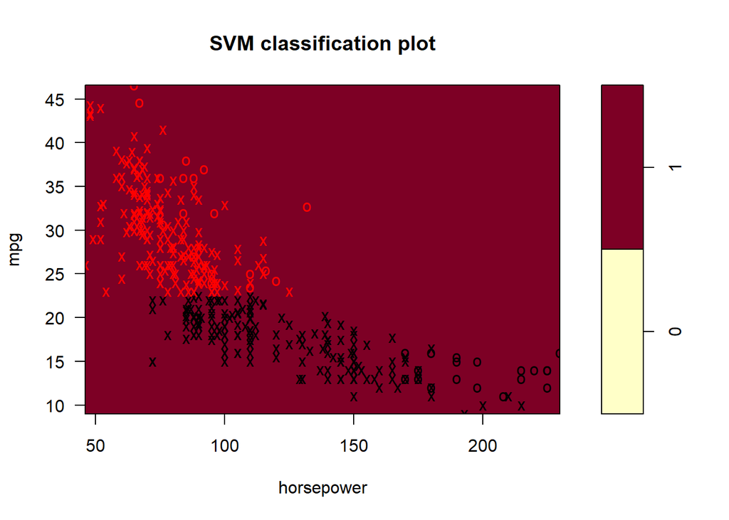

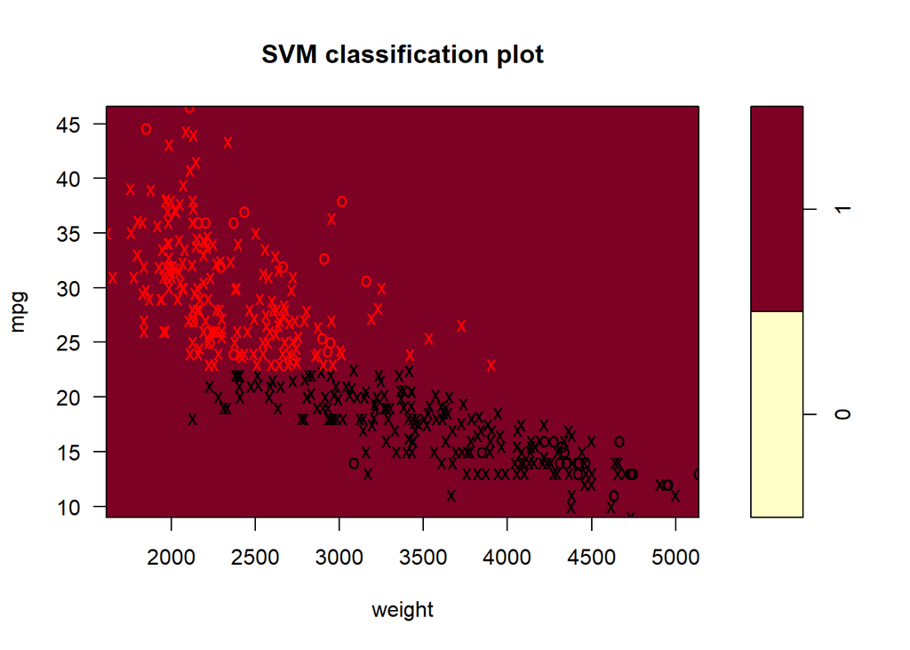

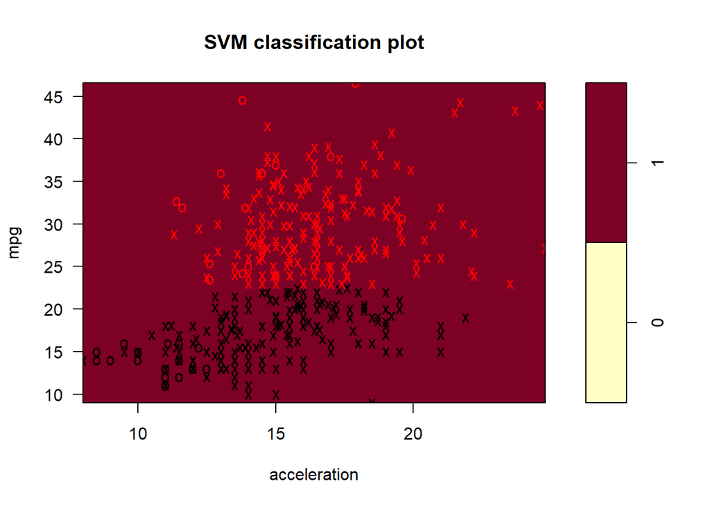

[9 more figures not shown]

## Ejercicio 8

**Este problema involucra el conjunto de datos “OJ” que es parte del paquete ISLR.**

**a) Cree un conjunto de entrenamiento que contenga una muestra aleatoria de 800 observaciones, y un conjunto de prueba que contenga las observaciones restantes.**

Dividimos el set de datos

**b) Ajuste un clasificador de vector de soporte a los datos de entrenamiento usando “costo” = 0.01, con “Compra” como respuesta y las otras variables como predictores. Use la función summary () para generar estadísticas resumidas y describir los resultados obtenidos.**

Creamos el modelo y revisamos el resumen

```
##
## Call:
## svm(formula = Purchase ~ ., data = train_oj, kernel = "linear", cost = 0.01)
##
##
## Parameters:
##    SVM-Type:  C-classification
##  SVM-Kernel:  linear
##        cost:  0.01
##
## Number of Support Vectors:  432
##
##  ( 215 217 )
##
##
## Number of Classes:  2
##
## Levels:
##  CH MM
```

El svm ha creado 432 vectores de soporte de 800 puntos de entrenamiento. De estos, 217 pertenecen al nivel MM y los 215 restantes pertenecen al nivel CH. *

**c) ¿Cuáles son las tasas de error de capacitación y prueba?**

Realizamos las predicciones en entrenamiento y revisamos la matriz de confusión

```
## Confusion Matrix and Statistics
##
##           Reference
## Prediction  CH  MM
##         CH 432  60
##         MM  77 231
##
##                Accuracy : 0.8288
##                  95% CI : (0.8008, 0.8542)
##     No Information Rate : 0.6362
##     P-Value [Acc > NIR] : <2e-16
##
##                   Kappa : 0.6346
##
##  Mcnemar's Test P-Value : 0.1716
##
##             Sensitivity : 0.8487
##             Specificity : 0.7938
##          Pos Pred Value : 0.8780
##          Neg Pred Value : 0.7500
##              Prevalence : 0.6362
##          Detection Rate : 0.5400
##    Detection Prevalence : 0.6150
##       Balanced Accuracy : 0.8213
##
##        'Positive' Class : CH
##
```

La tasa de error en entrenamiento es de 17.12%

Realizamos las predicciones en pruebas y revisamos la matriz de confusión

```
## Confusion Matrix and Statistics
##
##           Reference
## Prediction  CH  MM
##         CH 142  19
##         MM  25  84
##
##                Accuracy : 0.837
##                  95% CI : (0.7875, 0.879)
##     No Information Rate : 0.6185
##     P-Value [Acc > NIR] : 3.442e-15
##
##                   Kappa : 0.6585
##
##  Mcnemar's Test P-Value : 0.451
##
##             Sensitivity : 0.8503
##             Specificity : 0.8155
##          Pos Pred Value : 0.8820
##          Neg Pred Value : 0.7706
##              Prevalence : 0.6185
##          Detection Rate : 0.5259
##    Detection Prevalence : 0.5963
##       Balanced Accuracy : 0.8329
##
##        'Positive' Class : CH
##
```

La tasa de error en prueba es de 16.3%

**d) Use la función tune () para seleccionar un “costo” óptimo. Considere valores en el rango de 0.01 a 10.**

```
##
## Parameter tuning of 'svm':
##
## - sampling method: 10-fold cross validation
##
## - best parameters:
##  cost
##     1
##
## - best performance: 0.175
##
## - Detailed performance results:
##           cost   error dispersion
## 1   0.01000000 0.17750 0.02415229
## 2   0.01778279 0.17625 0.02664713
## 3   0.03162278 0.17625 0.02913689
## 4   0.05623413 0.18125 0.03498512
## 5   0.10000000 0.17625 0.03356689
## 6   0.17782794 0.17625 0.02913689
## 7   0.31622777 0.17750 0.02874698
## 8   0.56234133 0.17875 0.02503470
## 9   1.00000000 0.17500 0.02886751
## 10  1.77827941 0.18000 0.02140872
## 11  3.16227766 0.18000 0.02648375
## 12  5.62341325 0.18625 0.02972676
## 13 10.00000000 0.18625 0.02729087
```

Encontramos el error mínimo con el cost igual a 1.

**e) Calcule las tasas de error de capacitación y prueba utilizando este nuevo valor para “costo”.**

```
## Confusion Matrix and Statistics
##
##           Reference
## Prediction  CH  MM
##         CH 434  58
##         MM  76 232
##
##                Accuracy : 0.8325
##                  95% CI : (0.8048, 0.8577)
##     No Information Rate : 0.6375
##     P-Value [Acc > NIR] : <2e-16
##
##                   Kappa : 0.6424
##
##  Mcnemar's Test P-Value : 0.1419
##
##             Sensitivity : 0.8510
##             Specificity : 0.8000
##          Pos Pred Value : 0.8821
##          Neg Pred Value : 0.7532
##              Prevalence : 0.6375
##          Detection Rate : 0.5425
##    Detection Prevalence : 0.6150
##       Balanced Accuracy : 0.8255
##
##        'Positive' Class : CH
##
```

```
## Confusion Matrix and Statistics
##
##           Reference
## Prediction  CH  MM
##         CH 140  21
##         MM  23  86
##
##                Accuracy : 0.837
##                  95% CI : (0.7875, 0.879)
##     No Information Rate : 0.6037
##     P-Value [Acc > NIR] : <2e-16
##
##                   Kappa : 0.6605
##
##  Mcnemar's Test P-Value : 0.8802
##
##             Sensitivity : 0.8589
##             Specificity : 0.8037
##          Pos Pred Value : 0.8696
##          Neg Pred Value : 0.7890
##              Prevalence : 0.6037
##          Detection Rate : 0.5185
##    Detection Prevalence : 0.5963
##       Balanced Accuracy : 0.8313
##
##        'Positive' Class : CH
##
```

Vemos que el menor error en entrenamiento es de 16.75% y en prueba es de 16.3%.

**f) Repita las partes (b) a (e) usando una máquina de vectores de soporte con un kernel radial. Use el valor predeterminado para “gamma”.**

```
##
## Call:
## svm(formula = Purchase ~ ., data = train_oj, kernel = "radial")
##
##
## Parameters:
##    SVM-Type:  C-classification
##  SVM-Kernel:  radial
##        cost:  1
##
## Number of Support Vectors:  375
##
##  ( 183 192 )
##
##
## Number of Classes:  2
##
## Levels:
##  CH MM
```

```
## Confusion Matrix and Statistics
##
##           Reference
## Prediction  CH  MM
##         CH 453  39
##         MM  81 227
##
##                Accuracy : 0.85
##                  95% CI : (0.8233, 0.874)
##     No Information Rate : 0.6675
##     P-Value [Acc > NIR] : < 2.2e-16
##
##                   Kappa : 0.675
##
##  Mcnemar's Test P-Value : 0.000182
##
##             Sensitivity : 0.8483
##             Specificity : 0.8534
##          Pos Pred Value : 0.9207
##          Neg Pred Value : 0.7370
##              Prevalence : 0.6675
##          Detection Rate : 0.5663
##    Detection Prevalence : 0.6150
##       Balanced Accuracy : 0.8508
##
##        'Positive' Class : CH
##
```

```
## Confusion Matrix and Statistics
##
##           Reference
## Prediction  CH  MM
##         CH 146  15
##         MM  28  81
##
##                Accuracy : 0.8407
##                  95% CI : (0.7915, 0.8823)
##     No Information Rate : 0.6444
##     P-Value [Acc > NIR] : 6.094e-13
##
##                   Kappa : 0.6627
##
##  Mcnemar's Test P-Value : 0.06725
##
##             Sensitivity : 0.8391
##             Specificity : 0.8438
##          Pos Pred Value : 0.9068
##          Neg Pred Value : 0.7431
##              Prevalence : 0.6444
##          Detection Rate : 0.5407
##    Detection Prevalence : 0.5963
##       Balanced Accuracy : 0.8414
##
##        'Positive' Class : CH
##
```

Usando el kernel radial y el gamma por defecto, encontramos un error en entrenamiento del 15% y uno de pruebas de: 15.93%.

```
##
## Parameter tuning of 'svm':
##
## - sampling method: 10-fold cross validation
##
## - best parameters:
##      cost
##  1.778279
##
## - best performance: 0.1775
##
## - Detailed performance results:
##           cost   error dispersion
## 1   0.01000000 0.38500 0.04199868
## 2   0.01778279 0.38500 0.04199868
## 3   0.03162278 0.35875 0.04715886
## 4   0.05623413 0.20125 0.04226652
## 5   0.10000000 0.18125 0.03784563
## 6   0.17782794 0.18750 0.04487637
## 7   0.31622777 0.19250 0.03446012
## 8   0.56234133 0.18375 0.03120831
## 9   1.00000000 0.18000 0.03343734
## 10  1.77827941 0.17750 0.03106892
## 11  3.16227766 0.18125 0.03784563
## 12  5.62341325 0.18375 0.03821086
## 13 10.00000000 0.19375 0.03738408
```

```
##
## Call:
## svm(formula = Purchase ~ ., data = train_oj, kernel = "radial", cost = tune_out$best.parameter$cost)
##
##
## Parameters:
##    SVM-Type:  C-classification
##  SVM-Kernel:  radial
##        cost:  1.778279
##
## Number of Support Vectors:  354
##
##  ( 171 183 )
##
##
## Number of Classes:  2
##
## Levels:
##  CH MM
```

```
## Confusion Matrix and Statistics
##
##           Reference
## Prediction  CH  MM
##         CH 453  39
##         MM  79 229
##
##                Accuracy : 0.8525
##                  95% CI : (0.826, 0.8764)
##     No Information Rate : 0.665
##     P-Value [Acc > NIR] : < 2.2e-16
##
##                   Kappa : 0.6808
##
##  Mcnemar's Test P-Value : 0.0003304
##
##             Sensitivity : 0.8515
##             Specificity : 0.8545
##          Pos Pred Value : 0.9207
##          Neg Pred Value : 0.7435
##              Prevalence : 0.6650
##          Detection Rate : 0.5663
##    Detection Prevalence : 0.6150
##       Balanced Accuracy : 0.8530
##
##        'Positive' Class : CH
##
```

```
## Confusion Matrix and Statistics
##
##           Reference
## Prediction  CH  MM
##         CH 146  15
##         MM  28  81
##
##                Accuracy : 0.8407
##                  95% CI : (0.7915, 0.8823)
##     No Information Rate : 0.6444
##     P-Value [Acc > NIR] : 6.094e-13
##
##                   Kappa : 0.6627
##
##  Mcnemar's Test P-Value : 0.06725
##
##             Sensitivity : 0.8391
##             Specificity : 0.8438
##          Pos Pred Value : 0.9068
##          Neg Pred Value : 0.7431
##              Prevalence : 0.6444
##          Detection Rate : 0.5407
##    Detection Prevalence : 0.5963
##       Balanced Accuracy : 0.8414
##
##        'Positive' Class : CH
##
```

El ajuste no redujo el error que observaamos en el punto anterior, aqui se tiene un error mínimo de 17.75% con costo 1.778.

**g) Repita las partes (b) a (e) usando una máquina de vectores de soporte con un kernel polinomial. Establecer “grado” = 2.**

```
##
## Call:
## svm(formula = Purchase ~ ., data = train_oj, kernel = "polynomial",
##     degree = 2)
##
##
## Parameters:
##    SVM-Type:  C-classification
##  SVM-Kernel:  polynomial
##        cost:  1
##      degree:  2
##      coef.0:  0
##
## Number of Support Vectors:  443
##
##  ( 217 226 )
##
##
## Number of Classes:  2
##
## Levels:
##  CH MM
```

```
## Confusion Matrix and Statistics
##
##           Reference
## Prediction  CH  MM
##         CH 461  31
##         MM 112 196
##
##                Accuracy : 0.8212
##                  95% CI : (0.7929, 0.8472)
##     No Information Rate : 0.7163
##     P-Value [Acc > NIR] : 3.731e-12
##
##                   Kappa : 0.603
##
##  Mcnemar's Test P-Value : 2.233e-11
##
##             Sensitivity : 0.8045
##             Specificity : 0.8634
##          Pos Pred Value : 0.9370
##          Neg Pred Value : 0.6364
##              Prevalence : 0.7163
##          Detection Rate : 0.5763
##    Detection Prevalence : 0.6150
##       Balanced Accuracy : 0.8340
##
##        'Positive' Class : CH
##
```

```
## Confusion Matrix and Statistics
##
##           Reference
## Prediction  CH  MM
##         CH 149  12
##         MM  41  68
##
##                Accuracy : 0.8037
##                  95% CI : (0.7512, 0.8494)
##     No Information Rate : 0.7037
##     P-Value [Acc > NIR] : 0.0001254
##
##                   Kappa : 0.574
##
##  Mcnemar's Test P-Value : 0.0001200
##
##             Sensitivity : 0.7842
##             Specificity : 0.8500
##          Pos Pred Value : 0.9255
##          Neg Pred Value : 0.6239
##              Prevalence : 0.7037
##          Detection Rate : 0.5519
##    Detection Prevalence : 0.5963
##       Balanced Accuracy : 0.8171
##
##        'Positive' Class : CH
##
```

Ahora probamos tuneando el modelo:

```
##
## Parameter tuning of 'svm':
##
## - sampling method: 10-fold cross validation
##
## - best parameters:
##      cost
##  3.162278
##
## - best performance: 0.18375
##
## - Detailed performance results:
##           cost   error dispersion
## 1   0.01000000 0.38625 0.04308019
## 2   0.01778279 0.36625 0.05775006
## 3   0.03162278 0.35500 0.04937104
## 4   0.05623413 0.31875 0.04868051
## 5   0.10000000 0.31625 0.05529278
## 6   0.17782794 0.25625 0.04759858
## 7   0.31622777 0.21250 0.03952847
## 8   0.56234133 0.19750 0.04199868
## 9   1.00000000 0.19250 0.04216370
## 10  1.77827941 0.18750 0.04750731
## 11  3.16227766 0.18375 0.05070681
## 12  5.62341325 0.18500 0.04031129
## 13 10.00000000 0.19000 0.03425801
```

```
##
## Call:
## svm(formula = Purchase ~ ., data = train_oj, kernel = "polynomial",
##     degree = 2, cost = tune_out$best.parameter$cost)
##
##
## Parameters:
##    SVM-Type:  C-classification
##  SVM-Kernel:  polynomial
##        cost:  3.162278
##      degree:  2
##      coef.0:  0
##
## Number of Support Vectors:  378
##
##  ( 185 193 )
##
##
## Number of Classes:  2
##
## Levels:
##  CH MM
```

```
## Confusion Matrix and Statistics
##
##           Reference
## Prediction  CH  MM
##         CH 457  35
##         MM  96 212
##
##                Accuracy : 0.8362
##                  95% CI : (0.8088, 0.8612)
##     No Information Rate : 0.6912
##     P-Value [Acc > NIR] : < 2.2e-16
##
##                   Kappa : 0.6409
##
##  Mcnemar's Test P-Value : 1.587e-07
##
##             Sensitivity : 0.8264
##             Specificity : 0.8583
##          Pos Pred Value : 0.9289
##          Neg Pred Value : 0.6883
##              Prevalence : 0.6913
##          Detection Rate : 0.5713
##    Detection Prevalence : 0.6150
##       Balanced Accuracy : 0.8424
##
##        'Positive' Class : CH
##
```

```
## Confusion Matrix and Statistics
##
##           Reference
## Prediction  CH  MM
##         CH 146  15
##         MM  30  79
##
##                Accuracy : 0.8333
##                  95% CI : (0.7834, 0.8758)
##     No Information Rate : 0.6519
##     P-Value [Acc > NIR] : 2.554e-11
##
##                   Kappa : 0.646
##
##  Mcnemar's Test P-Value : 0.03689
##
##             Sensitivity : 0.8295
##             Specificity : 0.8404
##          Pos Pred Value : 0.9068
##          Neg Pred Value : 0.7248
##              Prevalence : 0.6519
##          Detection Rate : 0.5407
##    Detection Prevalence : 0.5963
##       Balanced Accuracy : 0.8350
##
##        'Positive' Class : CH
##
```

Tuneando se reduce el error, ya que arroja un 16.38% en entrenamiento y un 16.67% en pruebas.

**h) En general, ¿qué enfoque parece dar los mejores resultados con estos datos?**

En general, con el kernel radial produjo el mejor rendimiento sin tunear los parámetros.